### Note on Labs and Assignments:

> 🔧 Look for the **wrench emoji** 🔧 — it highlights where you're expected to take action!

> These sections are graded and are not optional.

# IS 4487 Lab 5: EDA

## Outline

- Univariate analysis (distributions, histograms, counts)
- Bivariate analysis (correlations, scatterplots, group comparisons)
- Reflections and insights

This lab uses the same dataset from **Lab 4**. You will see some overlap in the initial tasks as the data is cleaned.

## SF Rentals - Business Context

This dataset represents actual rental listings in the San Francisco housing market, which is known for its high prices, competitive demand, and neighborhood-level variation. In a business context, this type of data could be used by real estate companies, rental platforms, investors, or property managers to better understand pricing trends and market dynamics. The variables provide multiple angles for analysis: pricing (price) can be compared with property features like size (sqft), bedrooms and bathrooms, and whether the listing is a full apartment or just a room; location data (nhood, lat, lon) allows for geographic analysis of rent differences across neighborhoods; and time variables (date, year) help track how the market changes over time. Text fields like title and descr can even be analyzed to understand how listings are marketed. By exploring this dataset, analysts can answer questions such as what factors drive higher rent, which neighborhoods are most expensive, or how prices have changed over time. This kind of analysis is valuable for setting competitive prices, identifying investment opportunities, and helping renters or companies make informed housing decisions.

Note that many of the columns (variables) will be empty. This is an unfortunate reality in the real world!

Some rentals are apartments, others are for homes, and there may be some other random properties for rent. Each row represents one rental listing.

**Source:** Pennington, Kate (2018). Bay Area Craigslist Rental Housing Posts, 2000-2018. Retrieved from [Github](https://github.com/katepennington/historic_bay_area_craigslist_housing_posts/blob/master/clean_2000_2018.csv.zip).

## Data Dictionary

| Variable | Type | Description |
| --- | --- | --- |
| `post_id` | Categorical | Unique listing ID |
| `date` | Numeric | Listing date (numeric format) |
| `year` | Integer | Year of listing |
| `nhood` | Categorical | Neighborhood |
| `city` | Categorical | City |
| `county` | Categorical | County |
| `price` | Numeric | Listing price (USD) |
| `beds` | Numeric | Number of bedrooms |
| `baths` | Numeric | Number of bathrooms |
| `sqft` | Numeric | Square footage |
| `room_in_apt` | Binary | Indicates whether the rental listing is for an entire apartment (0) or a single room within an apartment (1) |
| `address` | Categorical | Street address |
| `lat` | Numeric | Latitude |
| `lon` | Numeric | Longitude |
| `title` | Text | Listing title |
| `descr` | Text | Listing description |
| `details` | Text | Additional details |

## 1. Importing the Data

### Instructions:

- Import the `pandas` library for dataframes. Then `Matplotlib` and `Seaborn` for data visualization.
- Import data from the rent.csv into a dataframe from the tidytuesday link.
- Use `.info()` and `.head()` to inspect the structure and preview the data.

```python
import pandas as pd
import matplotlib.pyplot as plt
import seaborn as sns
import numpy as np
```

```python
url = 'https://raw.githubusercontent.com/Stan-Pugsley/is_4487_base/refs/heads/main/DataSets/rent.csv'
df = pd.read_csv(url, low_memory=False)
```

```python
# Get summary info
df.info()
```

```
<class 'pandas.DataFrame'>
RangeIndex: 200810 entries, 0 to 200809
Data columns (total 17 columns):
 #   Column       Non-Null Count   Dtype
---  ------       --------------   -----
 0   post_id      200810 non-null  str
 1   date         200797 non-null  str
 2   year         200796 non-null  float64
 3   nhood        200796 non-null  str
 4   city         200796 non-null  str
 5   county       199402 non-null  str
 6   price        200796 non-null  float64
 7   beds         194188 non-null  float64
 8   baths        42675 non-null   float64
 9   sqft         64679 non-null   float64
 10  room_in_apt  200796 non-null  float64
 11  address      3908 non-null    str
 12  lat          7651 non-null    float64
 13  lon          4312 non-null    float64
 14  title        198279 non-null  str
 15  descr        3254 non-null    str
 16  details      8015 non-null    str
dtypes: float64(8), str(9)
memory usage: 26.0 MB
```

```python
# Preview the first rows
df.head()
```

|  | post_id | date | year | nhood | city | county | price | beds | baths | sqft | room_in_apt | address | lat | lon | title | descr | details |
| --- | --- | --- | --- | --- | --- | --- | --- | --- | --- | --- | --- | --- | --- | --- | --- | --- | --- |
| 0 | pre2013_134138 | 20050111 | 2005.0 | alameda | alameda | alameda | 1250.0 | 2.0 | 2.0 | NaN | 0.0 | NaN | NaN | NaN | $1250 / 2br - 2BR/2BA 1145 ALAMEDA DE LAS PU... | NaN | NaN |
| 1 | pre2013_135669 | 20050126 | 2005.0 | alameda | alameda | alameda | 1295.0 | 2.0 | NaN | NaN | 0.0 | NaN | NaN | NaN | $1295 / 2br - Walk the Beach! 1 FREE MONTH + $... | NaN | NaN |
| 2 | pre2013_127127 | 20041017 | 2004.0 | alameda | alameda | alameda | 1100.0 | 2.0 | NaN | NaN | 0.0 | NaN | NaN | NaN | $1100 / 2br - cottage | NaN | NaN |
| 3 | pre2013_68671 | 20120601 | 2012.0 | alameda | alameda | alameda | 1425.0 | 1.0 | NaN | 735.0 | 0.0 | NaN | NaN | NaN | $1425 / 1br - 735ft² - BEST LOCATION SOUTHSHOR... | NaN | NaN |
| 4 | pre2013_127580 | 20041021 | 2004.0 | alameda | alameda | alameda | 890.0 | 1.0 | NaN | NaN | 0.0 | NaN | NaN | NaN | $890 / 1br - Classy "Painted Lady" VICTORIAN -... | NaN | NaN |

## 2. Inspecting Data Quality

### Instructions:

- Check for outliers or invalid data in key numeric variables like `price`, `sqft`, `beds`, or `baths`. The concept of outliers will be covered more in week 6. This week we will just look for outliers, but we won't take steps to remove them.

```python
# Basic summary statistics
df[['price', 'beds', 'baths', 'sqft']].describe()
```

|  | price | beds | baths | sqft |
| --- | --- | --- | --- | --- |
| count | 200796.000000 | 194188.000000 | 42675.000000 | 64679.000000 |
| mean | 2135.362746 | 1.889025 | 1.679086 | 1201.827688 |
| std | 1427.747903 | 1.079138 | 0.690509 | 5000.217864 |
| min | 220.000000 | 0.000000 | 1.000000 | 80.000000 |
| 25% | 1295.000000 | 1.000000 | 1.000000 | 750.000000 |
| 50% | 1800.000000 | 2.000000 | 2.000000 | 1000.000000 |
| 75% | 2505.000000 | 3.000000 | 2.000000 | 1360.000000 |
| max | 40000.000000 | 12.000000 | 8.000000 | 900000.000000 |

### Reflection:

- 2.1 Do any numeric variables contain extreme or unusual values?
- 2.2 Should those outlier values be removed? Or are they valid rental properties?

### ✍️ Your Response:

**2.1** Yes, and `sqft` is the worst offender. Its maximum is 900,000 square feet against a median of 1,000, and the standard deviation comes out at 5,000 while the interquartile range is only 750 to 1,360. A standard deviation several times wider than the middle half of the data is the signature of a few extreme values dragging the whole distribution. The 99th percentile sits at 3,800, so everything above that is a thin tail of implausible entries. The skew statistic is 172.8, where anything above 1 is already considered heavily skewed.

`price` is skewed but defensible. The minimum of 220 is low for the Bay Area and the maximum of 40,000 per month is extreme, but the skew of 4.28 is the shape you would expect from any housing market with a luxury segment. `beds` reaches 12 and `baths` reaches 8, both of which are possible in a large house.

**2.2** They should not all be treated the same way, and the distinction is whether the value is *impossible* or merely *unusual*.

The 900,000 square foot listings are almost certainly land parcels or lot sizes entered into the wrong field, not living space. Those are errors and should be removed. Inspecting the 12-bedroom listings makes the same point from a different angle: all three are priced between 1,150 and 1,650 per month with no bathroom or square footage recorded. A 12-bedroom property renting for 1,315 in Sausalito is not a 12-bedroom property. These are almost certainly room-share listings where the poster entered the total bedrooms in the building rather than the unit.

The genuinely expensive listings are a different case. A 40,000 per month rental in Atherton or Pacific Heights is a real product in this market. Deleting it would remove legitimate information about the top of the distribution, which matters to anyone studying luxury rentals.

The practical consequence is measurable, and it shows up in Section 4 below. On the raw data the correlation between `sqft` and `price` is only 0.074, which would lead an analyst to conclude that size barely affects rent. After filtering out the impossible square footage values the same correlation jumps to 0.487, making it the strongest predictor in the file. The outliers were not just noise. They were actively hiding the most important relationship in the dataset.

## 3. Univariate Analysis

Explore individual variables to understand their distributions and frequency.

### Tasks:

- Plot histograms for numeric variables (`price`, `sqft`)
- Plot countplots for categorical variables (`beds`, `nhood`)

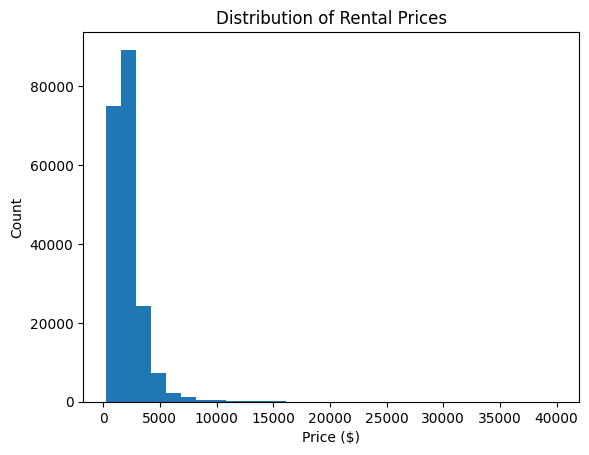

```python
# Histogram: Price
plt.hist(df['price'], bins=30)
plt.title("Distribution of Rental Prices")
plt.xlabel("Price ($)")
plt.ylabel("Count")
plt.show()
```

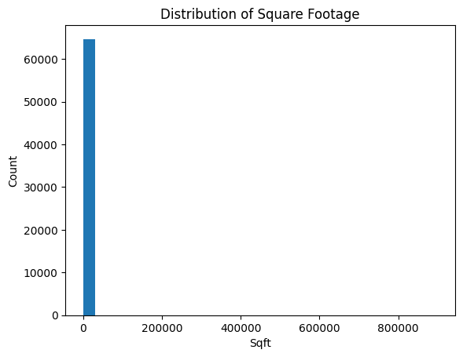

```python
# Histogram: Square Footage
plt.hist(df['sqft'].dropna(), bins=30)
plt.title("Distribution of Square Footage")
plt.xlabel("Sqft")
plt.ylabel("Count")
plt.show()
```

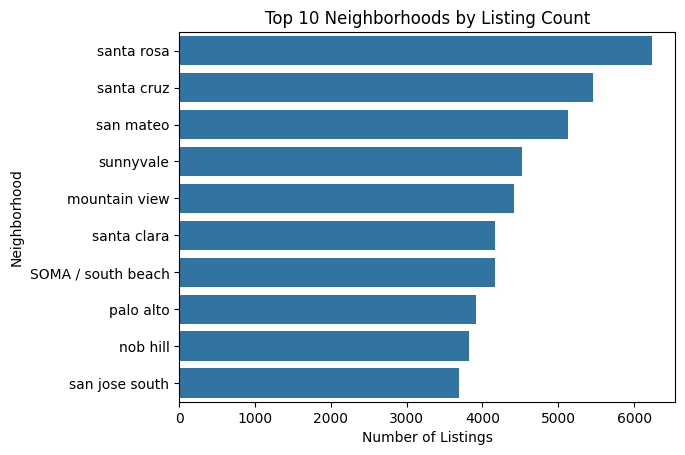

```python
# Bar plot of top 10 neighborhoods by number of listings
top_nhoods = df['nhood'].value_counts().head(10)

sns.barplot(x=top_nhoods.values, y=top_nhoods.index)
plt.title("Top 10 Neighborhoods by Listing Count")
plt.xlabel("Number of Listings")
plt.ylabel("Neighborhood")
plt.show()
```

### 🔧 Do the following – Part 3

1. Create two new visualizations using different variables than the ones already shown above.
- A **histogram** of the `baths` variable
- A **bar chart** showing the **average square footage by number of bathrooms**

> Be sure to label your axes and include a title for each chart.

> Suggestions:

### Reflection:

After creating each of the visuals, write 1–2 sentences explaining what you notice in each.

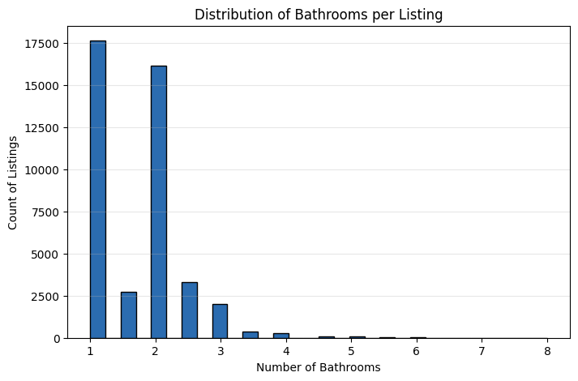

```
baths
1.0    17644
1.5     2710
2.0    16172
2.5     3309
3.0     2016
3.5      386
4.0      258
4.5       73
Name: count, dtype: int64
```

```python
# Visual 1: Histogram of the baths variable
plt.figure(figsize=(8, 5))
plt.hist(df['baths'].dropna(), bins=30, color='#2b6cb0', edgecolor='black')
plt.title("Distribution of Bathrooms per Listing")
plt.xlabel("Number of Bathrooms")
plt.ylabel("Count of Listings")
plt.grid(axis='y', alpha=0.3)
plt.show()

print(df['baths'].value_counts().sort_index().head(8))
```

### ✍️ Visual 1 Response:

1. The distribution is sharply bimodal rather than bell shaped, with 17,644 listings at exactly 1 bathroom and 16,172 at exactly 2, and comparatively few in between. The half-bath values (1.5 at 2,710 listings, 2.5 at 3,309) form small secondary spikes, which tells us this variable behaves like a category with a handful of common levels rather than a continuous measurement. Everything above 4 bathrooms totals fewer than 200 listings out of the 42,675 that report the field at all, so the right tail is thin enough that any statistic computed there rests on very few observations.

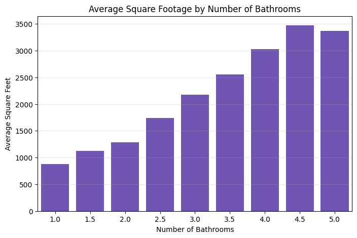

```
         mean  count
baths
1.0     882.0   5496
1.5    1120.0    778
2.0    1289.0   5654
2.5    1739.0   1398
3.0    2179.0    914
3.5    2554.0    219
4.0    3028.0    108
4.5    3473.0     36
5.0    3370.0     39
```

```python
# Visual 2: Average square footage by number of bathrooms
avg_sqft_baths = df.groupby('baths')['sqft'].mean()
avg_sqft_baths = avg_sqft_baths[avg_sqft_baths.index <= 5]

plt.figure(figsize=(8, 5))
sns.barplot(x=avg_sqft_baths.index, y=avg_sqft_baths.values, color='#6b46c1')
plt.title("Average Square Footage by Number of Bathrooms")
plt.xlabel("Number of Bathrooms")
plt.ylabel("Average Square Feet")
plt.grid(axis='y', alpha=0.3)
plt.show()

print(df.groupby('baths')['sqft'].agg(['mean', 'count']).round(0).head(9))
```

## 4. Bivariate Analysis

Explore relationships between two variables to understand how features like square footage or bedrooms influence price.

```python
# Correlation matrix
corr_matrix = df[['price', 'beds', 'baths', 'sqft']].corr()
corr_matrix
```

|  | price | beds | baths | sqft |
| --- | --- | --- | --- | --- |
| price | 1.000000 | 0.450096 | 0.433553 | 0.074310 |
| beds | 0.450096 | 1.000000 | 0.651835 | 0.707235 |
| baths | 0.433553 | 0.651835 | 1.000000 | 0.645372 |
| sqft | 0.074310 | 0.707235 | 0.645372 | 1.000000 |

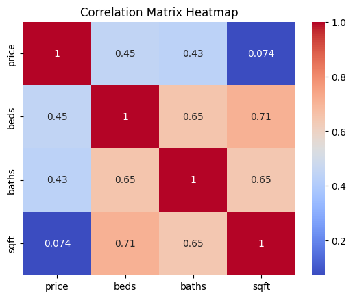

```python
# Heatmap of correlation matrix
sns.heatmap(corr_matrix, annot=True, cmap='coolwarm')
plt.title("Correlation Matrix Heatmap")
plt.show()
```

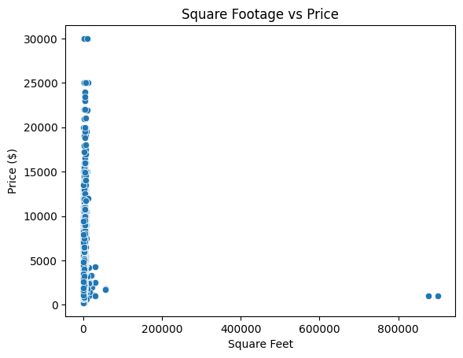

```python
# Scatterplot: Square Footage vs Price
sns.scatterplot(x='sqft', y='price', data=df)
plt.title("Square Footage vs Price")
plt.xlabel("Square Feet")
plt.ylabel("Price ($)")
plt.show()
```

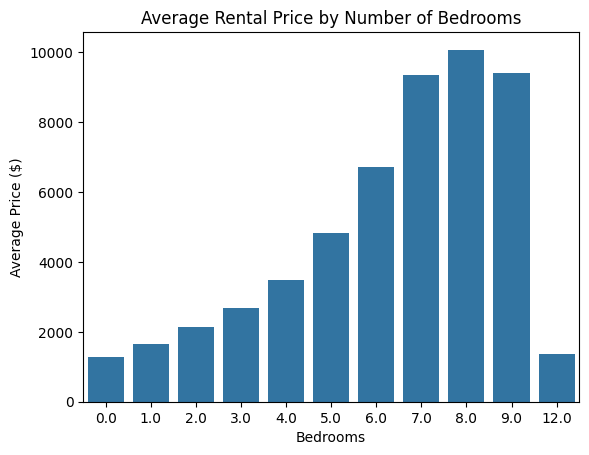

```python
# Average price by number of bedrooms
avg_price_beds = df.groupby('beds')['price'].mean().sort_index()
sns.barplot(x=avg_price_beds.index, y=avg_price_beds.values)
plt.title("Average Rental Price by Number of Bedrooms")
plt.xlabel("Bedrooms")
plt.ylabel("Average Price ($)")
plt.show()
```

### 🔧 Do the following – Part 4

- 4.1 Create a scatterplot of `baths` vs `price`.
- 4.2 Group by `year` and plot the average price over time.

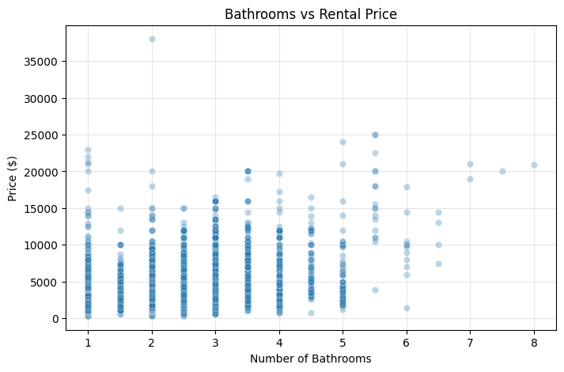

```
         mean  median  count
baths
1.0    1857.0  1600.0  17644
1.5    2140.0  1800.0   2710
2.0    2543.0  2250.0  16172
2.5    2964.0  2500.0   3309
3.0    3753.0  3000.0   2016
3.5    5240.0  4198.0    386
4.0    4997.0  4095.0    258
4.5    6700.0  5399.0     73
5.0    5422.0  3997.0     71
```

```python
# 4.1 Scatterplot of baths vs price
plt.figure(figsize=(8, 5))
sns.scatterplot(x='baths', y='price', data=df, alpha=0.3)
plt.title("Bathrooms vs Rental Price")
plt.xlabel("Number of Bathrooms")
plt.ylabel("Price ($)")
plt.grid(alpha=0.3)
plt.show()

print(df.groupby('baths')['price'].agg(['mean', 'median', 'count']).round(0).head(9))
```

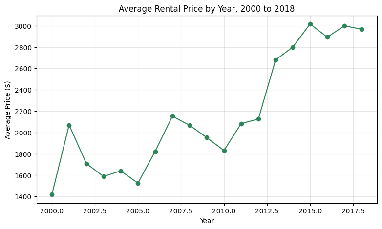

```
year
2000.0    1419.0
2001.0    2070.0
2002.0    1709.0
2003.0    1588.0
2004.0    1640.0
2005.0    1525.0
2006.0    1823.0
2007.0    2152.0
2008.0    2068.0
2009.0    1952.0
2010.0    1831.0
2011.0    2083.0
2012.0    2126.0
2013.0    2680.0
2014.0    2800.0
2015.0    3016.0
2016.0    2893.0
2017.0    2999.0
2018.0    2967.0
Name: price, dtype: float64
```

```python
# 4.2 Group by year and plot the average price over time
avg_price_year = df.groupby('year')['price'].mean().sort_index()

plt.figure(figsize=(9, 5))
plt.plot(avg_price_year.index, avg_price_year.values, marker='o', color='#2f855a')
plt.title("Average Rental Price by Year, 2000 to 2018")
plt.xlabel("Year")
plt.ylabel("Average Price ($)")
plt.grid(alpha=0.3)
plt.show()

print(avg_price_year.round(0))
```

```python
# Supporting evidence for the outlier discussion in 2.2:
# how the sqft-to-price correlation changes once impossible values are removed

filtered = df[(df['sqft'] < 20000) & (df['price'] < df['price'].quantile(0.99))]

print("RAW correlation with price:")
print(df[['price', 'beds', 'baths', 'sqft']].corr()['price'].round(3))
print(f"\nFILTERED correlation with price (sqft < 20,000 and price below 99th percentile, n = {len(filtered):,}):")
print(filtered[['price', 'beds', 'baths', 'sqft']].corr()['price'].round(3))
```

```
RAW correlation with price:
price    1.000
beds     0.450
baths    0.434
sqft     0.074
Name: price, dtype: float64

FILTERED correlation with price (sqft < 20,000 and price below 99th percentile, n = 63,657):
price    1.000
beds     0.414
baths    0.360
sqft     0.487
Name: price, dtype: float64
```

### Reflection:

4.1 What trends or outliers do you see?

### ✍️ Your Response:

**4.1** The bathroom scatterplot shows price rising with bathroom count, but the spread widens dramatically as you move right. At 1 and 2 bathrooms the points form dense vertical columns with most listings clustered between roughly 1,000 and 3,000 dollars, which is a tight and predictable market. Past 4 bathrooms the points scatter across an enormous range, and the group means become unstable: 5 bathrooms averages 5,422 while 5.5 bathrooms averages 15,873. That reversal is not a market signal. It is 17 listings at 5.5 baths against 71 at 5, and a handful of luxury properties dominating a tiny sample. Any conclusion drawn from the right side of this chart is built on almost no data.

Two cautions on both charts. The listing counts per year are wildly uneven, from 23 records in 2000 to 41,847 in 2004, so the early points carry almost no weight despite being plotted at equal visual prominence. And because these are means rather than medians, every point is pulled upward by the luxury tail identified in 2.1.

## 🔧 Part 5: Reflection

Answer the following questions in the markdown cell below (no more than a few sentences per question required)

- 5.1 Which variables are most strongly correlated with rental price?
- 5.2 Are there patterns in how size (sqft) or number of bedrooms affects price?
- 5.3 Which neighborhoods or years show the highest prices?
- 5.4 What other visualizations or groupings might improve this analysis?

Use this section to summarize insights from both Labs 4 and 5.

### ✍️ Your Response:

**5.1 Which variables are most strongly correlated with rental price?**

The answer depends entirely on whether outliers have been cleaned, which is the central lesson of this lab. On the raw data the correlations with price are `beds` at 0.450, `baths` at 0.434, and `sqft` at just 0.074. Read at face value, that says square footage barely matters, which contradicts everything known about housing markets.

Once the impossible square footage values are removed, `sqft` becomes the strongest predictor at 0.487, ahead of `beds` at 0.414 and `baths` at 0.360. A single contaminated variable was suppressing the true relationship by a factor of six. This is the practical case for cleaning before analyzing rather than after.

**5.2 Are there patterns in how size or number of bedrooms affects price?**

Both rise with price, but neither is linear. Average price by bedroom count climbs steadily from 1,280 at 0 bedrooms to 10,079 at 8, then breaks: the 9-bedroom average drops to 9,425 and the 12-bedroom average collapses to 1,372. That collapse is a data quality artifact, not a market finding. All three 12-bedroom listings rent between 1,150 and 1,650 with no bathrooms or square footage recorded, which means they are almost certainly room shares where the poster entered the building's total bedroom count.

**5.3 Which neighborhoods or years show the highest prices?**

Inverness leads at 5,310 average, followed by Atherton at 4,536, Tiburon and Belvedere at 4,265, the Financial District at 3,958, and West Portal and Forest Hills at 3,827. The pattern splits into two distinct types of expensive: wealthy low-density communities north and south of the city, and dense high-demand districts inside San Francisco itself. Those are different markets that happen to reach similar price points by different routes.

By year, 2015 is the peak at 3,016 average, with 2017 and 2018 close behind at 2,999 and 2,967. Rent roughly doubled across the 2000 to 2018 span.

**5.4 What other visualizations or groupings might improve this analysis?**

A price per square foot column would normalize away unit size and expose which neighborhoods are genuinely expensive rather than merely large, which is the metric a real estate professional would actually use.

Median rather than mean throughout. Every chart in this lab uses the mean, and with a price skew of 4.28 the mean sits above what a typical renter encounters. A median line plotted alongside the mean would show the gap directly.

Faceting price by year *within* neighborhood, so appreciation rates can be compared across areas. The current year chart aggregates the entire Bay Area and hides the fact that different neighborhoods almost certainly appreciated at very different rates.

Weighting or annotating charts by sample size. The bathroom and bedroom charts both display categories built on fewer than 20 observations at the same visual weight as categories built on 70,000, which invites exactly the misreading described in 4.1.

## Export Your Notebook to Submit in Canvas

- Use the instructions from Lab 1

```python
# !jupyter nbconvert --to html "lab_05_eda.ipynb"
```